# twelfth

rita

2023-04-01

## **Weight and MPG of Cars**

```r
cor.test(mtcars$wt, mtcars$mpg)
```

```
##
##  Pearson's product-moment correlation
##
## data:  mtcars$wt and mtcars$mpg
## t = -9.559, df = 30, p-value = 1.294e-10
## alternative hypothesis: true correlation is not equal to 0
## 95 percent confidence interval:
##  -0.9338264 -0.7440872
## sample estimates:
##        cor
## -0.8676594
```

The two variables, weight and mpg, have a strong negative relationship as evident from both the Pearson test (above) and the graph (below).

A Pearson test correlation that is close to -1 is evident of a strong negative relationship and these two factors got a -0.87.

And as seen on the graph weight visibly increases mpg goes down.

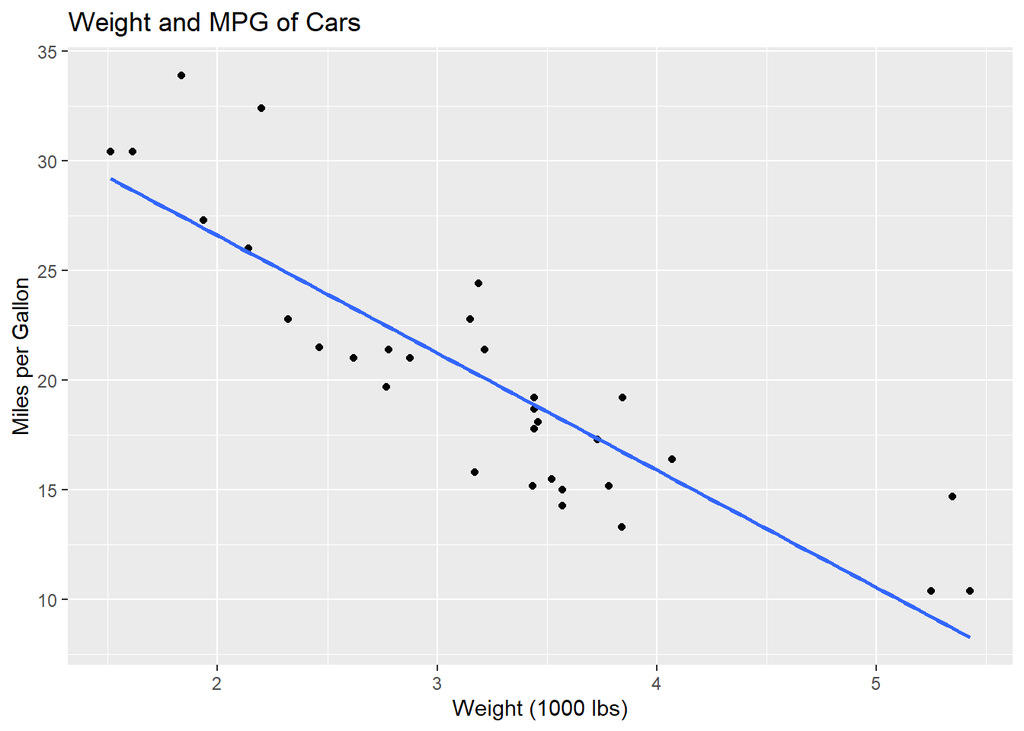

## **Weight, MPG, and Type of Engine of Cars**

```r
cor.test(mtcars$mpg, mtcars$vs)
```

```
##
##  Pearson's product-moment correlation
##
## data:  mtcars$mpg and mtcars$vs
## t = 4.8644, df = 30, p-value = 3.416e-05
## alternative hypothesis: true correlation is not equal to 0
## 95 percent confidence interval:
##  0.4103630 0.8223262
## sample estimates:
##       cor
## 0.6640389
```

MPG and engine shape have a moderate to strong positive relationship as evident from both the Pearson test and the graph.

The Pearson test correlation close to 1 is evident of a strong positive relationship, but this is only a .66 which is a little over halfway there.

Cars with a higher mpg tend to have straight shaped engine. That can be easily seen on the graph as the upper half the y-axis tends to just be straight shaped. But there is a good mix of both in the middle.

```r
cor.test(mtcars$wt, mtcars$vs)
```

```
##
##  Pearson's product-moment correlation
##
## data:  mtcars$wt and mtcars$vs
## t = -3.6535, df = 30, p-value = 0.0009798
## alternative hypothesis: true correlation is not equal to 0
## 95 percent confidence interval:
##  -0.7571117 -0.2556982
## sample estimates:
##        cor
## -0.5549157
```

Weight and engine shape have a moderate negative relationship as evident from both the Pearson test and the graph.

The Pearson test correlation close to -1 is evident of a strong negative relationship, but this is only a -.55.

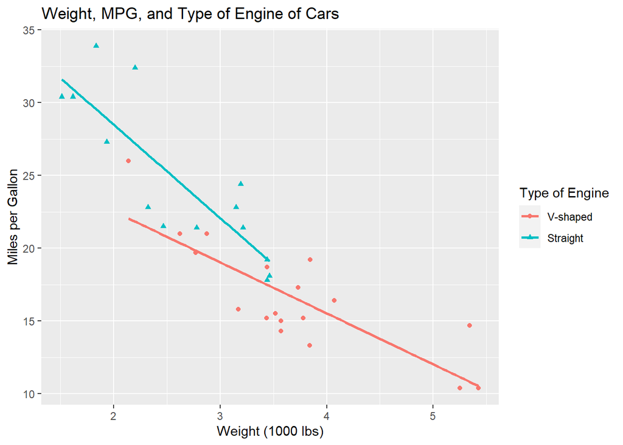